# ggplot2 ecosystem & designing visualizations

Lecture 11

Dr. Colin Rundel

# The wider ggplot2 ecosystem

# ggthemes

## ggplot2 themes

```r
g = ggplot( palmerpenguins::penguins, aes(x=species, y=body_mass_g, fill=species)) +
    geom_boxplot()
```

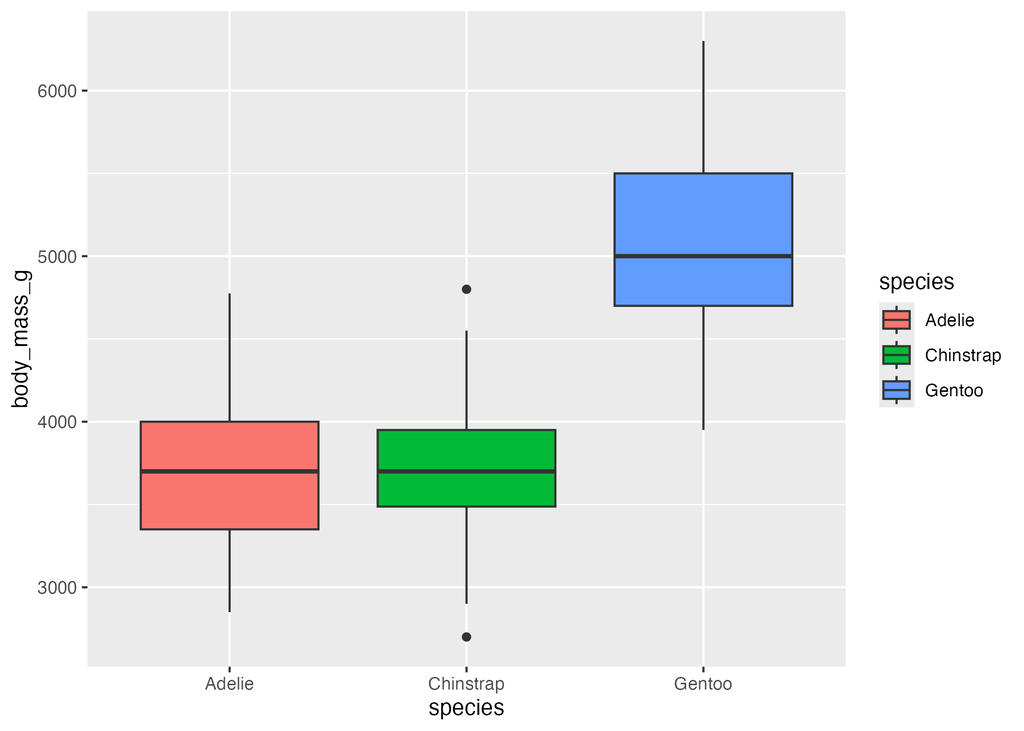

```r
g
```

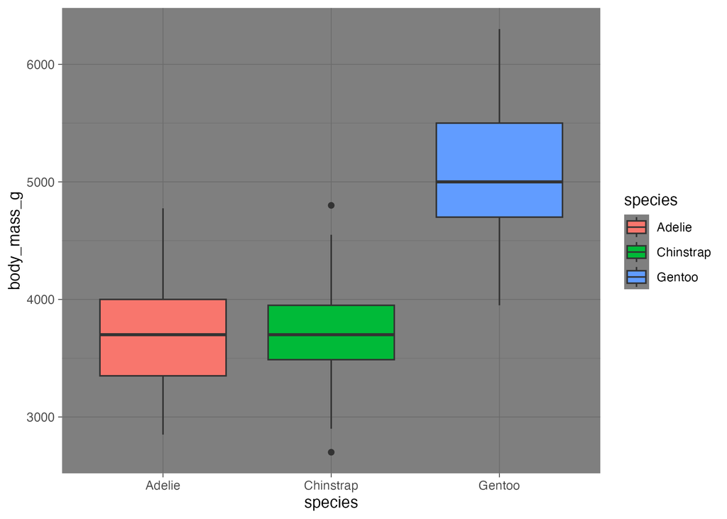

```r
g + theme_dark()
```

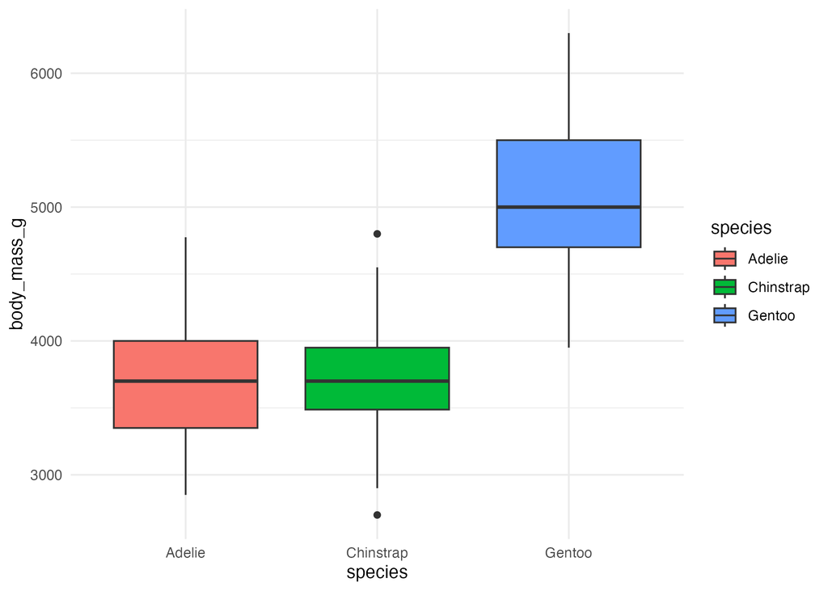

```r
g + theme_minimal()
```

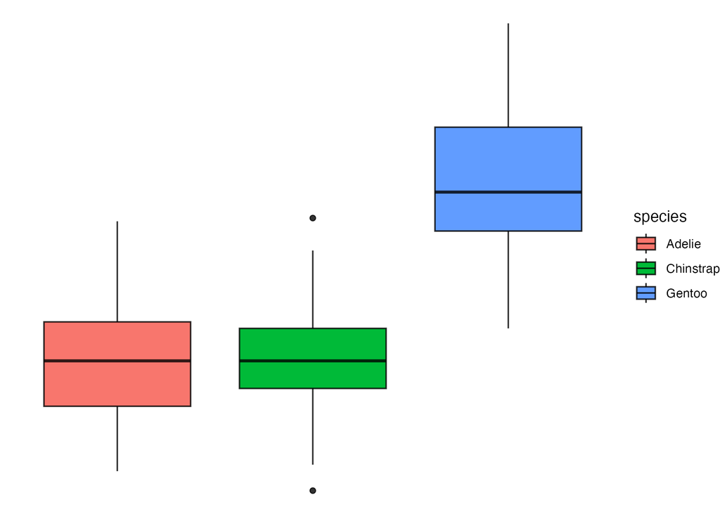

```r
g + theme_void()
```

## ggthemes

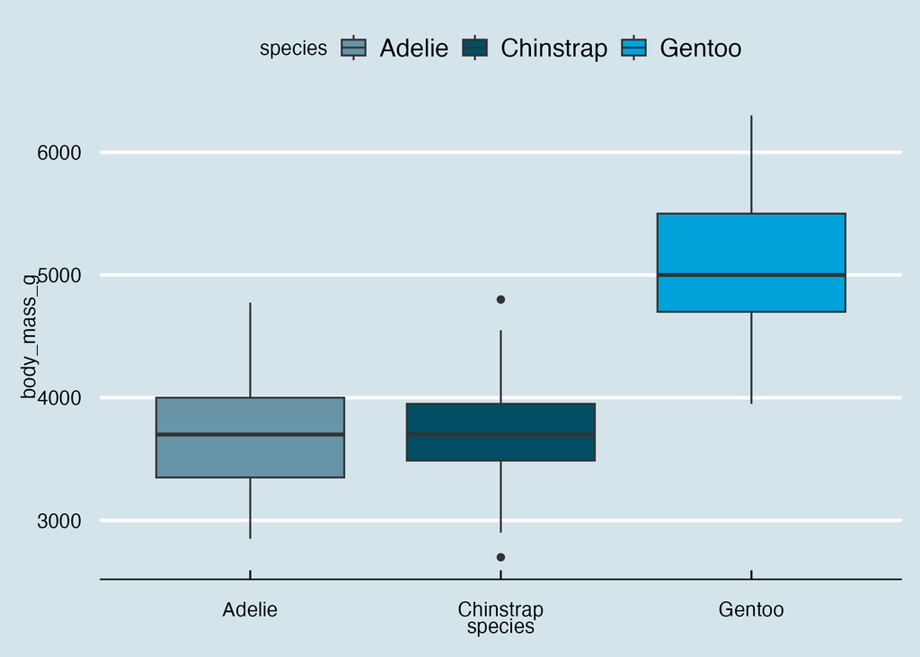

```r
g + ggthemes::theme_economist() +
  ggthemes::scale_fill_economist()
```

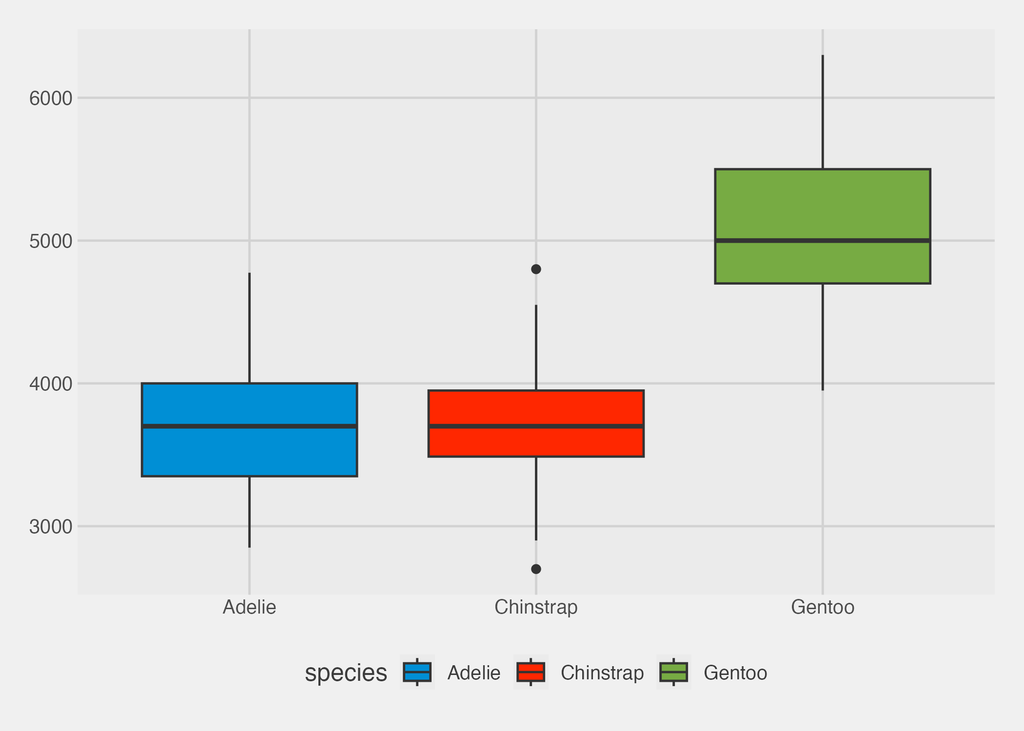

```r
g + ggthemes::theme_fivethirtyeight() +
  ggthemes::scale_fill_fivethirtyeight()
```

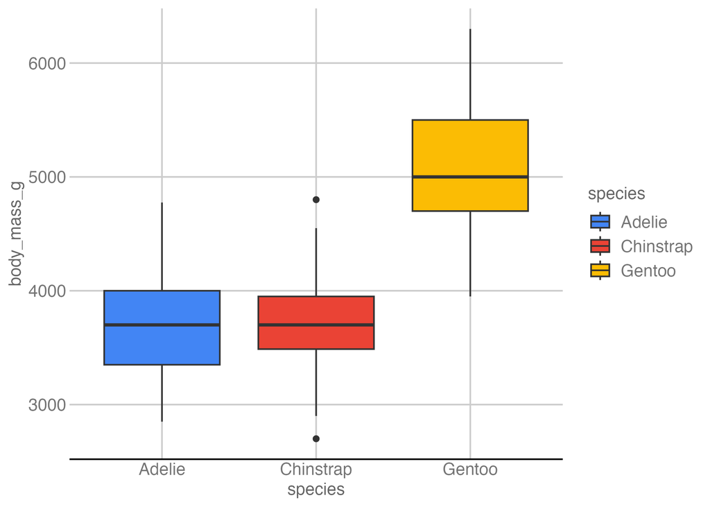

```r
g + ggthemes::theme_gdocs() +
  ggthemes::scale_fill_gdocs()
```

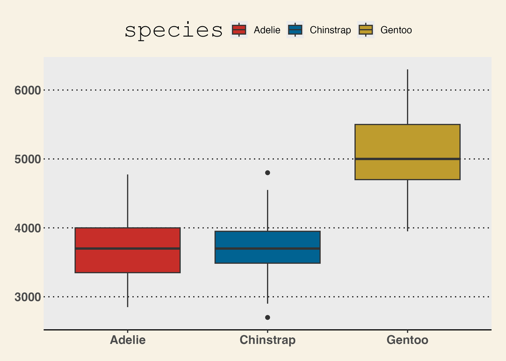

```r
g + ggthemes::theme_wsj() +
  ggthemes::scale_fill_wsj()
```

## And for those who miss Excel

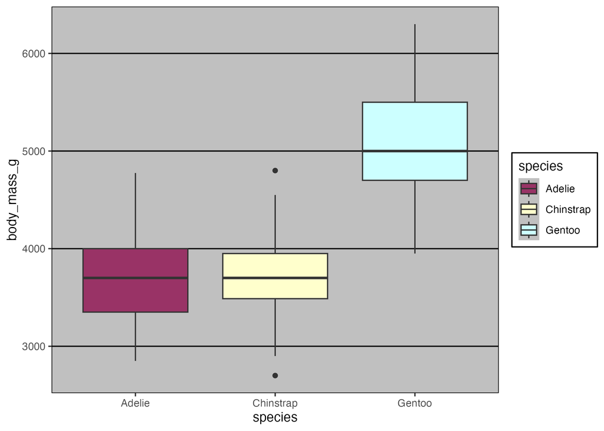

```r
g + ggthemes::theme_excel() +
  ggthemes::scale_fill_excel()
```

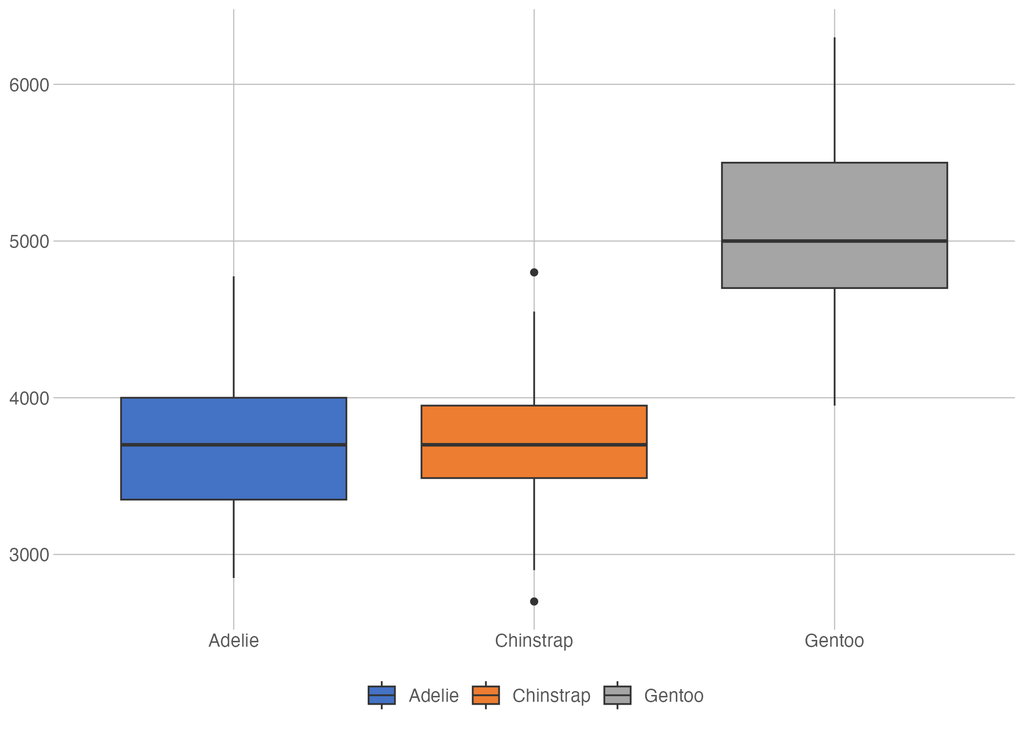

```r
g + ggthemes::theme_excel_new() +
  ggthemes::scale_fill_excel_new()
```

[figure not shown]

```r
d = tibble(
  car = rownames(mtcars),
  weight = mtcars$wt,
  mpg = mtcars$mpg
) |>
  filter(weight > 2.75, weight < 3.45)
```

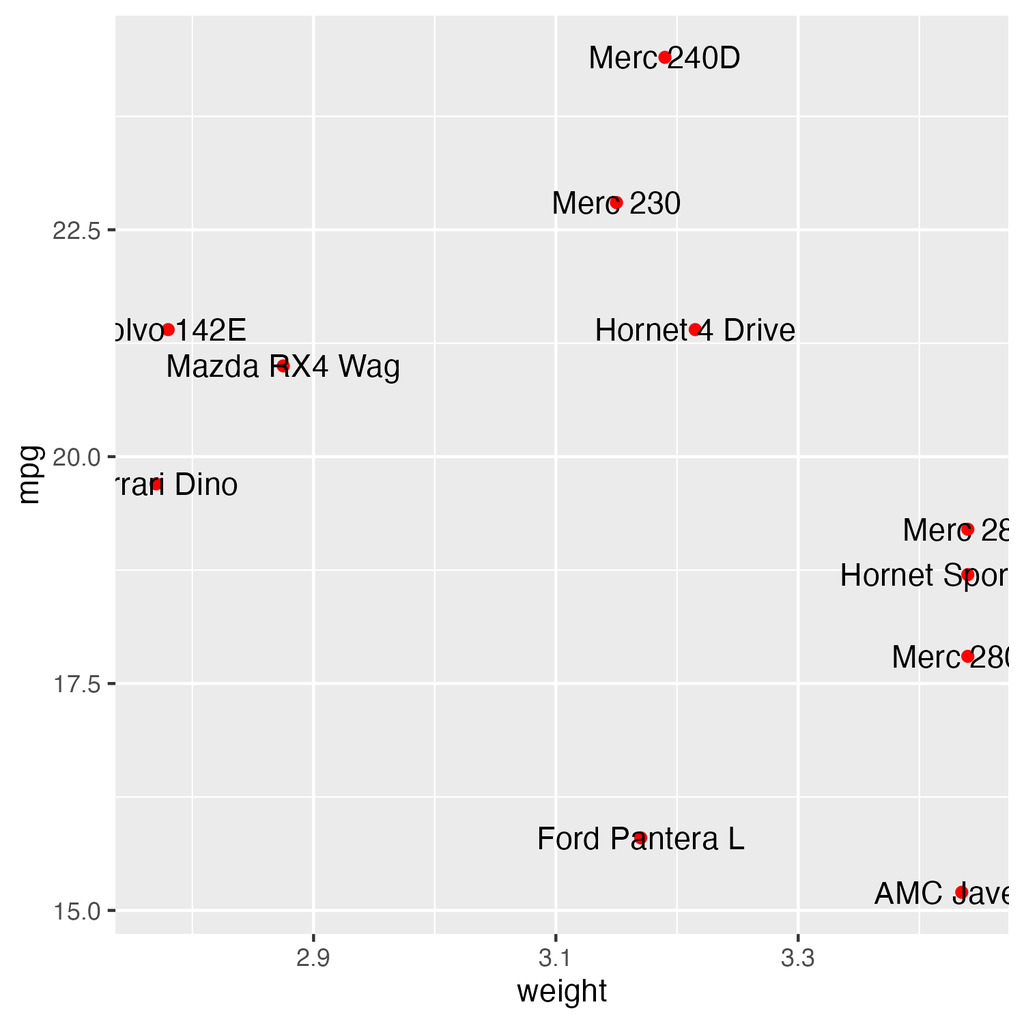

```r
ggplot(d, aes(x=weight, y=mpg)) +
  geom_point(color="red") +
  geom_text(
    aes(label = car)
  )
```

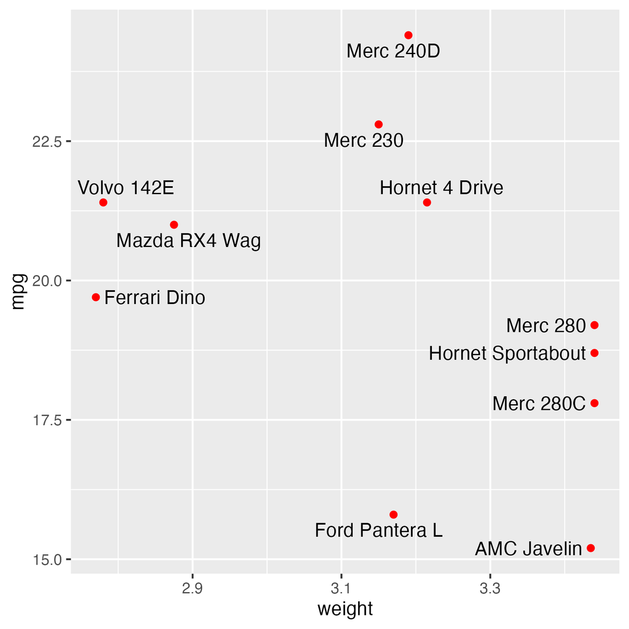

```r
ggplot(d, aes(x=weight, y=mpg)) +
  geom_point(color="red") +
  ggrepel::geom_text_repel(
    aes(label = car)
  )
```

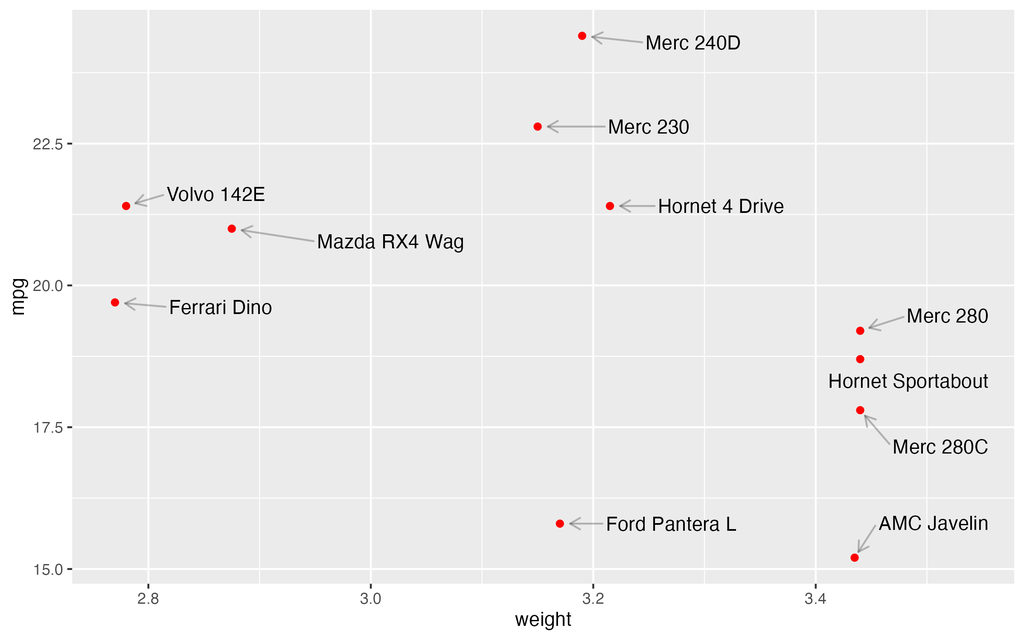

```r
ggplot(d, aes(x=weight, y=mpg)) +
  geom_point(color="red") +
  ggrepel::geom_text_repel(
    aes(label = car),
    nudge_x = .1, box.padding = 1, point.padding = 0.6,
    arrow = arrow(length = unit(0.02, "npc")), segment.alpha = 0.25
  )
```

[figure not shown]

## ggplot objects

```r
library(patchwork)

p1 = ggplot(palmerpenguins::penguins) +
  geom_boxplot(aes(x = island, y = body_mass_g))

p2 = ggplot(palmerpenguins::penguins) +
  geom_boxplot(aes(x = species, y = body_mass_g))

p3 = ggplot(palmerpenguins::penguins) +
  geom_point(aes(x = flipper_length_mm, y = body_mass_g, color = sex))

p4 = ggplot(palmerpenguins::penguins) +
  geom_point(aes(x = bill_length_mm, y = body_mass_g, color = sex))
```

```r
class(p1)
```

```
[1] "ggplot2::ggplot" "ggplot"          "ggplot2::gg"     "S7_object"
[5] "gg"
```

```r
p1 + p2 + p3 + p4
```

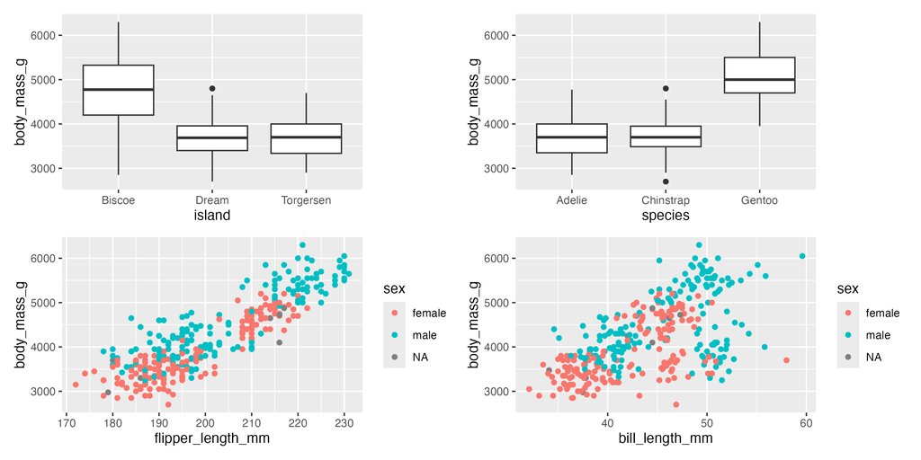

```r
p1 + p2 + p3 + p4 + plot_layout(nrow=1)
```

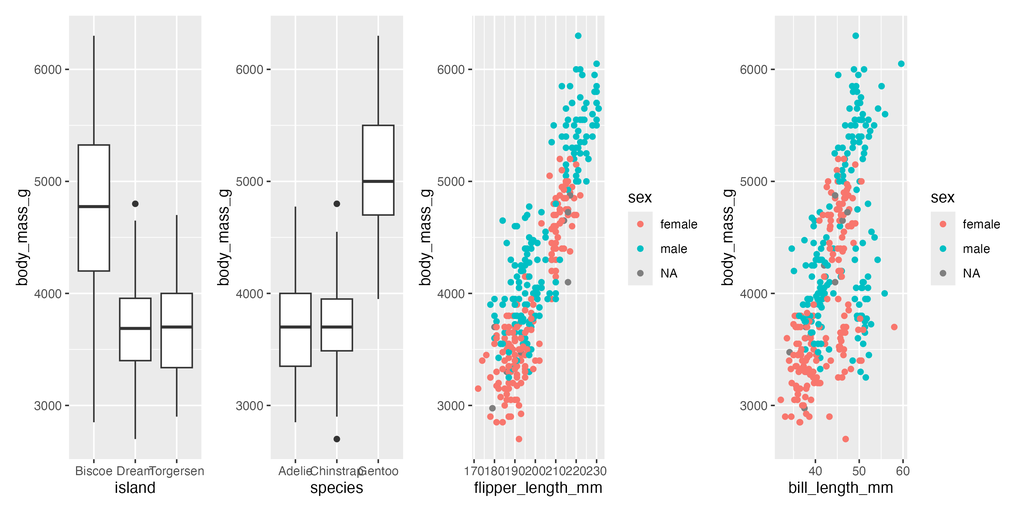

```r
p1 / (p2 + p3 + p4)
```

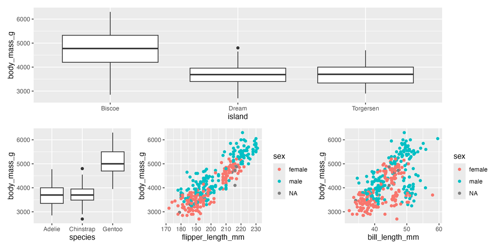

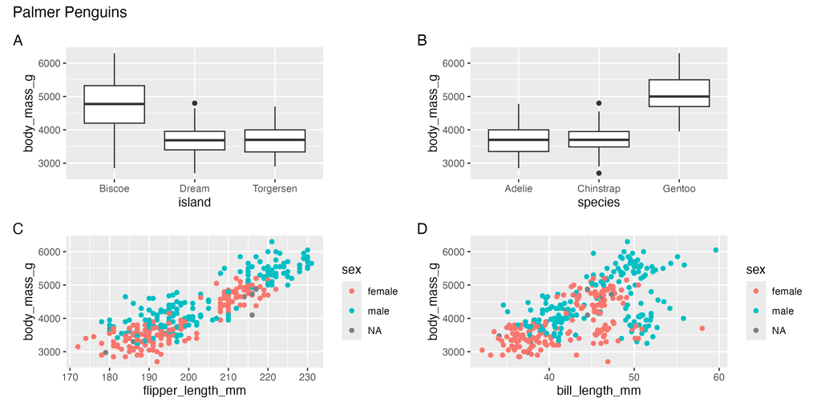

```r
p1 + p2 + p3 + p4 +
  plot_annotation(title = "Palmer Penguins", tag_levels = c("A"))
```

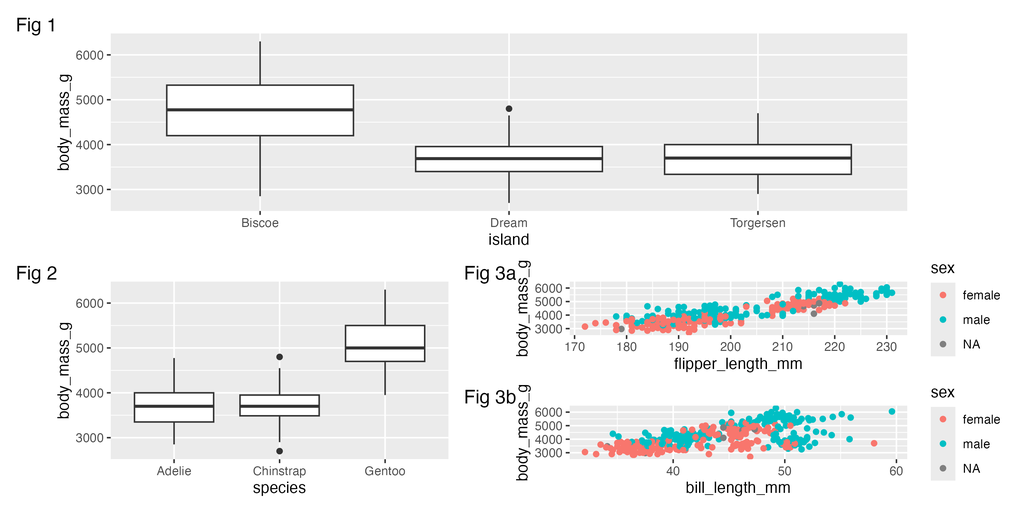

```r
p1 + {
  p2 + {
    p3 + p4 + plot_layout(ncol = 1) + plot_layout(tag_level = 'new')
  }
} +
  plot_layout(ncol = 1) +
  plot_annotation(tag_levels = c("1","a"), tag_prefix = "Fig ")
```

# GGally

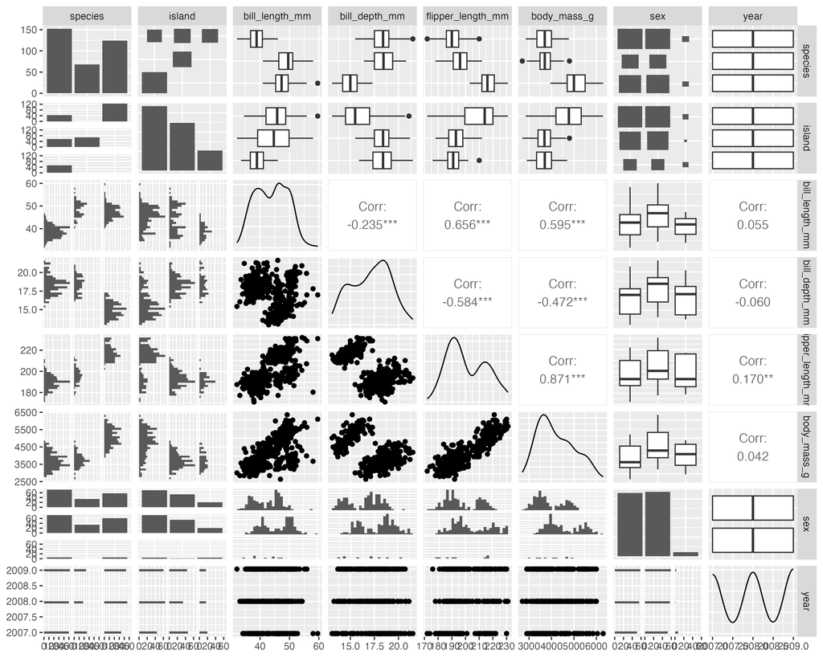

```r
GGally::ggpairs(palmerpenguins::penguins)
```

[figure not shown]

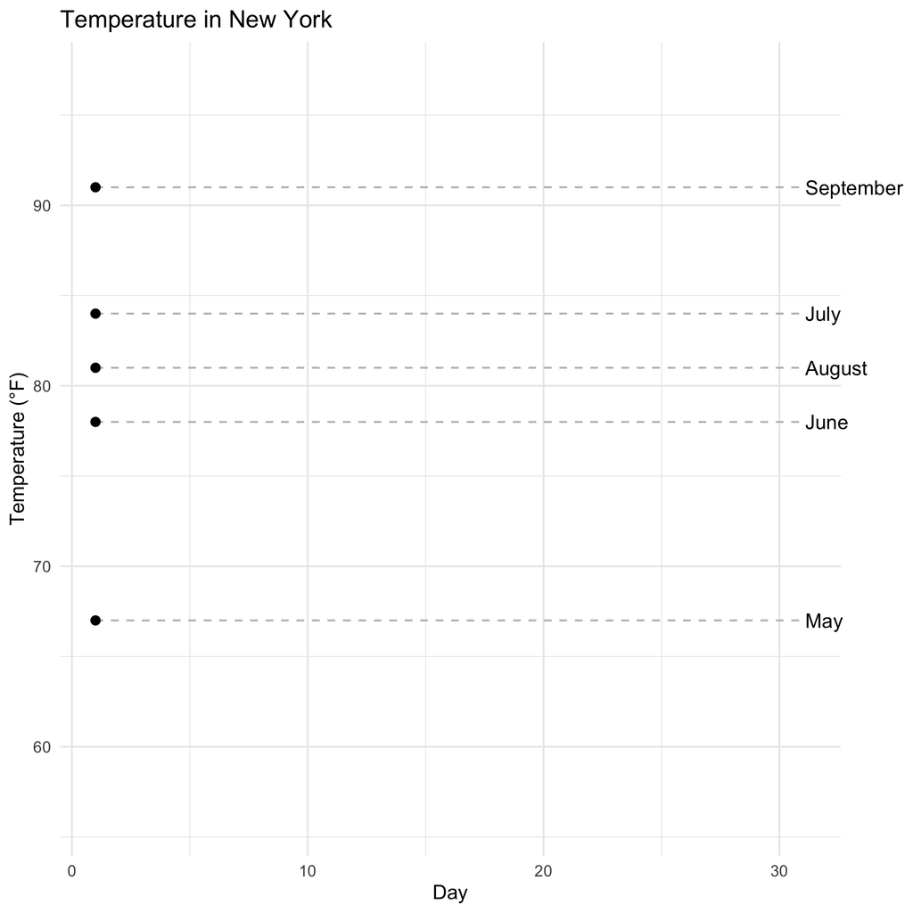

```r
airq = airquality
airq$Month = month.name[airq$Month]

ggplot(
  airq,
  aes(Day, Temp, group = Month)
) +
  geom_line() +
  geom_segment(
    aes(xend = 31, yend = Temp),
    linetype = 2,
    colour = 'grey'
  ) +
  geom_point(size = 2) +
  geom_text(
    aes(x = 31.1, label = Month),
    hjust = 0
  ) +
  gganimate::transition_reveal(Day) +
  coord_cartesian(clip = 'off') +
  labs(
    title = 'Temperature in New York',
    y = 'Temperature (°F)'
  ) +
  theme_minimal() +
  theme(plot.margin = margin(5.5, 40, 5.5, 5.5))
```

github.com/thomasp85/gganimate

## Some other notable packages

- [`marquee`](https://marquee.r-lib.org/) - add rendered markdown to your plots
- [`thematic`](https://rstudio.github.io/thematic/) & [`brand.yml`](https://posit-dev.github.io/brand-yml/) - automatic theming of plots to match your app / site
- [`ggridges`](https://cran.r-project.org/web/packages/ggridges/vignettes/introduction.html) - creates ridgeline plots (stacked density plots)
- [`ggdist`](https://mjskay.github.io/ggdist/) - visualizations and utilities for distributions and uncertainty (think bayesian model output)
- [`legendry`](https://teunbrand.github.io/legendry/) - adds additional guides (legends) to ggplot2

## More extensions

exts.ggplot2.tidyverse.org/gallery/

[interactive chart not shown]

# Why do we visualize?

## Anscombe’s Quartet

```r
datasets::anscombe |> as_tibble()
```

```
# A tibble: 11 × 8
      x1    x2    x3    x4    y1    y2    y3    y4
   <dbl> <dbl> <dbl> <dbl> <dbl> <dbl> <dbl> <dbl>
 1    10    10    10     8  8.04  9.14  7.46  6.58
 2     8     8     8     8  6.95  8.14  6.77  5.76
 3    13    13    13     8  7.58  8.74 12.7   7.71
 4     9     9     9     8  8.81  8.77  7.11  8.84
 5    11    11    11     8  8.33  9.26  7.81  8.47
 6    14    14    14     8  9.96  8.1   8.84  7.04
 7     6     6     6     8  7.24  6.13  6.08  5.25
 8     4     4     4    19  4.26  3.1   5.39 12.5
 9    12    12    12     8 10.8   9.13  8.15  5.56
10     7     7     7     8  4.82  7.26  6.42  7.91
11     5     5     5     8  5.68  4.74  5.73  6.89
```

## Tidy anscombe

```r
(tidy_anscombe = datasets::anscombe |>
  pivot_longer(everything(), names_sep = 1, names_to = c("var", "group")) |>
  pivot_wider(id_cols = group, names_from = var,
              values_from = value, values_fn = list(value = list)) |>
  unnest(cols = c(x,y)))
```

```
# A tibble: 44 × 3
   group     x     y
   <chr> <dbl> <dbl>
 1 1        10  8.04
 2 1         8  6.95
 3 1        13  7.58
 4 1         9  8.81
 5 1        11  8.33
 6 1        14  9.96
 7 1         6  7.24
 8 1         4  4.26
 9 1        12 10.8
10 1         7  4.82
# ℹ 34 more rows
```

```r
tidy_anscombe |>
  group_by(group) |>
  summarize(
    mean_x = mean(x), mean_y = mean(y),
    sd_x = sd(x), sd_y = sd(y),
    cor = cor(x,y), .groups = "drop"
  )
```

```
# A tibble: 4 × 6
  group mean_x mean_y  sd_x  sd_y   cor
  <chr>  <dbl>  <dbl> <dbl> <dbl> <dbl>
1 1          9   7.50  3.32  2.03 0.816
2 2          9   7.50  3.32  2.03 0.816
3 3          9   7.5   3.32  2.03 0.816
4 4          9   7.50  3.32  2.03 0.817
```

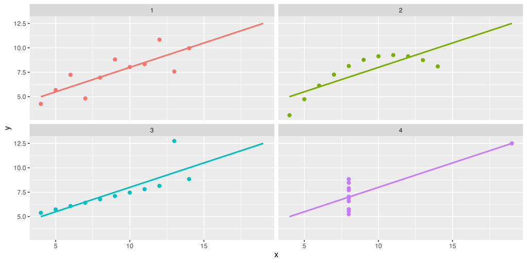

```r
ggplot(tidy_anscombe, aes(x = x, y = y, color = as.factor(group))) +
  geom_point(size=2) +
  facet_wrap(~group) +
  geom_smooth(method="lm", se=FALSE, fullrange=TRUE, formula = y~x) +
  guides(color="none")
```

## DatasauRus

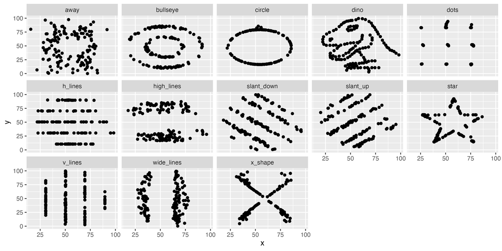

```r
ggplot(datasauRus::datasaurus_dozen, aes(x = x, y = y)) +
  geom_point() +
  facet_wrap(~dataset, ncol=5)
```

See [here](https://www.autodesk.com/research/publications/same-stats-different-graphs) for the original paper

[figure not shown]

```r
datasauRus::datasaurus_dozen
```

```
# A tibble: 1,846 × 3
   dataset     x     y
   <chr>   <dbl> <dbl>
 1 dino     55.4  97.2
 2 dino     51.5  96.0
 3 dino     46.2  94.5
 4 dino     42.8  91.4
 5 dino     40.8  88.3
 6 dino     38.7  84.9
 7 dino     35.6  79.9
 8 dino     33.1  77.6
 9 dino     29.0  74.5
10 dino     26.2  71.4
# ℹ 1,836 more rows
```

```r
datasauRus::datasaurus_dozen |>
  group_by(dataset) |>
  summarize(mean_x = mean(x), mean_y = mean(y),
            sd_x = sd(x), sd_y = sd(y),
            cor = cor(x,y), .groups = "drop")
```

```
# A tibble: 13 × 6
   dataset    mean_x mean_y  sd_x  sd_y     cor
   <chr>       <dbl>  <dbl> <dbl> <dbl>   <dbl>
 1 away         54.3   47.8  16.8  26.9 -0.0641
 2 bullseye     54.3   47.8  16.8  26.9 -0.0686
 3 circle       54.3   47.8  16.8  26.9 -0.0683
 4 dino         54.3   47.8  16.8  26.9 -0.0645
 5 dots         54.3   47.8  16.8  26.9 -0.0603
 6 h_lines      54.3   47.8  16.8  26.9 -0.0617
 7 high_lines   54.3   47.8  16.8  26.9 -0.0685
 8 slant_down   54.3   47.8  16.8  26.9 -0.0690
 9 slant_up     54.3   47.8  16.8  26.9 -0.0686
10 star         54.3   47.8  16.8  26.9 -0.0630
11 v_lines      54.3   47.8  16.8  26.9 -0.0694
12 wide_lines   54.3   47.8  16.8  26.9 -0.0666
13 x_shape      54.3   47.8  16.8  26.9 -0.0656
```

## Simpson’s Paradox

```r
lm(y~x, data=simpsons) |>
  summary()
```

```
Call:
lm(formula = y ~ x, data = simpsons)

Residuals:
    Min      1Q  Median      3Q     Max
-38.988 -10.208  -0.707   9.874  42.642

Coefficients:
             Estimate Std. Error t value Pr(>|t|)
(Intercept) -41.20220    3.51007  -11.74   <2e-16 ***
x             1.81324    0.06993   25.93   <2e-16 ***
---
Signif. codes:  0 '***' 0.001 '**' 0.01 '*' 0.05 '.' 0.1 ' ' 1

Residual standard error: 13.93 on 215 degrees of freedom
Multiple R-squared:  0.7577,    Adjusted R-squared:  0.7566
F-statistic: 672.2 on 1 and 215 DF,  p-value: < 2.2e-16
```

## Simpson’s Paradox Visually

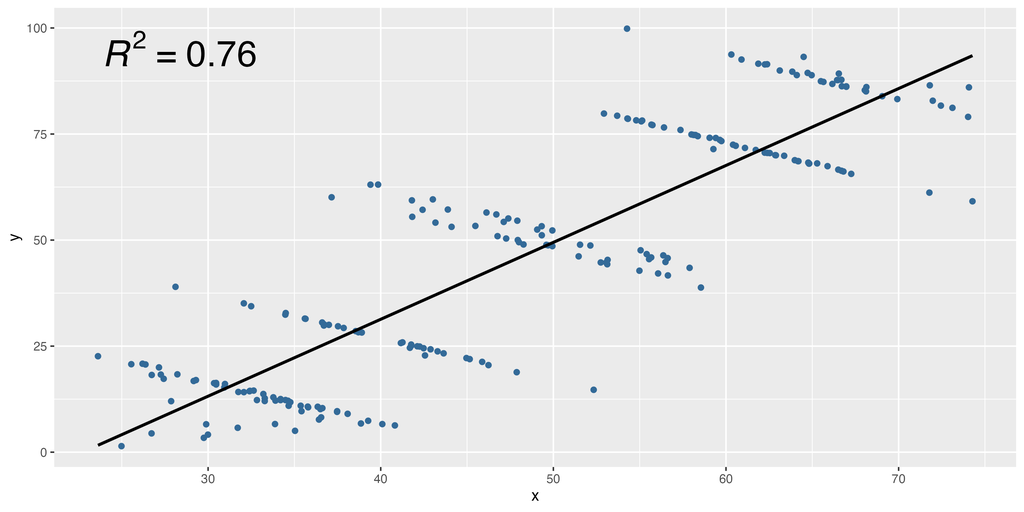

## Simpson’s Paradox with groups

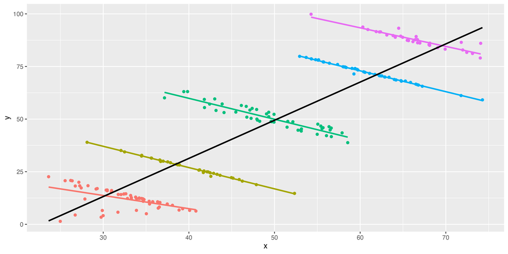

## Revised model

```r
lm(y~x*group-1, data=simpsons) |>
  summary()
```

```
Call:
lm(formula = y ~ x * group - 1, data = simpsons)

Residuals:
     Min       1Q   Median       3Q      Max
-15.4264  -0.6137   0.0811   1.0448   5.0613

Coefficients:
          Estimate Std. Error t value Pr(>|t|)
x         -0.62658    0.07987  -7.846 2.27e-13 ***
group1    32.50512    2.61640  12.424  < 2e-16 ***
group2    67.38858    3.47010  19.420  < 2e-16 ***
group3    99.63330    3.34565  29.780  < 2e-16 ***
group4   132.39316    4.76158  27.804  < 2e-16 ***
group5   146.36456    6.78530  21.571  < 2e-16 ***
x:group2  -0.38394    0.11747  -3.268 0.001267 **
x:group3  -0.36743    0.10440  -3.519 0.000532 ***
x:group4  -0.36425    0.11146  -3.268 0.001268 **
x:group5  -0.25654    0.12950  -1.981 0.048917 *
---
Signif. codes:  0 '***' 0.001 '**' 0.01 '*' 0.05 '.' 0.1 ' ' 1

Residual standard error: 2.474 on 207 degrees of freedom
Multiple R-squared:  0.998, Adjusted R-squared:  0.9979
F-statistic: 1.044e+04 on 10 and 207 DF,  p-value: < 2.2e-16
```